# PCA of mixed data with R

## The **gironde** dataset.

The dataset **gironde** is available in the R package **PCAmixdata**. This dataset is a list of 4 datatables and **housing** is one of them.

```r
library(PCAmixdata)
data(gironde)
housing <- gironde$housing
head(housing)
```

```
##                    density primaryres   houses owners council
## ABZAC                  132         89  inf 90%     64  sup 5%
## AILLAS                  21         88  sup 90%     77  inf 5%
## AMBARES-ET-LAGRAVE     532         95  inf 90%     66  sup 5%
## AMBES                  101         94  sup 90%     67  sup 5%
## ANDERNOS-LES-BAINS     552         62  inf 90%     72  inf 5%
## ANGLADE                 64         81  sup 90%     81  inf 5%
```

## Three functions to perform PCA of mixed data

Principal Component Analysis of mixed data is available in the following three functions :

- `PCAmix` of the R package **PCAmixdata**
- `FAMD` of the R package **FactoMineR**
- `dudi.mix`of the R package **ade4**

```r
library(PCAmixdata)
library(FactoMineR)
library(ade4)
```

The functions `PCAmix`, `FADM` and `dudi.mix` are used to perform PCA of the mixed dataset `housing`.

```r
# PCAmix (PCAmixdata)
split <- splitmix(housing)
pcamix <- PCAmix(X.quanti=split$X.quanti,
                 X.quali=split$X.quali,
                 rename.level=TRUE,
                 graph=FALSE, ndim=2)
# FAMD (FactoMineR)
famd <- FAMD(housing,
             graph = FALSE, ncp = 2)

# dudi.mix (ade4)
dudimix <- dudi.mix(housing,
                 scannf = FALSE, nf = 2)
```

## Comparison of the three functions

### Principal Components

Principal components are the coordinates of the projection of the $n$ observations (also called individuals) on the factor maps.

All the three functions give the same principal component scores.

```r
head(pcamix$scores)
```

```
##                    dim 1  dim 2
## ABZAC               2.36  0.024
## AILLAS             -0.88  0.123
## AMBARES-ET-LAGRAVE  2.62  0.800
## AMBES               0.93  0.919
## ANDERNOS-LES-BAINS  1.18 -2.481
## ANGLADE            -1.01 -0.424
```

```r
head(famd$ind$coord)
```

```
##                    Dim.1  Dim.2
## ABZAC               2.36  0.024
## AILLAS             -0.88  0.123
## AMBARES-ET-LAGRAVE  2.62  0.800
## AMBES               0.93  0.919
## ANDERNOS-LES-BAINS  1.18 -2.481
## ANGLADE            -1.01 -0.424
```

```r
head(dudimix$li)
```

```
##   Axis1  Axis2
## 1 -2.36  0.024
## 2  0.88  0.123
## 3 -2.62  0.800
## 4 -0.93  0.919
## 5 -1.18 -2.481
## 6  1.01 -0.424
```

### Eigenvalues

The eigenvalues are the variances of the principal components. Because principal components are identical, all three functions give then same eigenvalues.

```r
pcamix$eig[1:2,1]
```

```
## dim 1 dim 2
##   2.5   1.1
```

```r
famd$eig[,1]
```

```
## comp 1 comp 2
##    2.5    1.1
```

```r
dudimix$eig[1:2]
```

```
## [1] 2.5 1.1
```

Moreover, the **total inertia** is by definition equal to $p_1+m-p_2=3+4-2=5$ and this total inertia is the sum of all the eigenvalues.

```r
sum(dudimix$eig)
```

```
## [1] 5
```

### Variables

#### Squared loadings

Squared loadings are :

- squared correlations with the principal components when the variables are numerical (`density`, `primaryres`, `owners`),
- correlation ratios with the principal components when the variables are categorical (`houses` and `council`).

Because principal components are identical, all the three functions give the same squared loadings.

```r
pcamix$sqload
```

```
##              dim 1 dim 2
## density    0.49550 0.061
## primaryres 0.00035 0.946
## owners     0.73651 0.017
## houses     0.68226 0.030
## council    0.61226 0.016
```

```r
famd$var$coord
```

```
##              Dim.1 Dim.2
## density    0.49550 0.061
## primaryres 0.00035 0.946
## owners     0.73651 0.017
## houses     0.68226 0.030
## council    0.61226 0.016
```

```r
dudimix$cr
```

```
##                RS1   RS2
## density    0.49550 0.061
## primaryres 0.00035 0.946
## houses     0.68226 0.030
## owners     0.73651 0.017
## council    0.61226 0.016
```

#### Levels coordinates

The coordinates of the projections on the levels on the factor maps are obtained with the three functions. The functions `PCAmix` and `dudi.mix` give the same results.

```r
pcamix$levels$coord
```

```
##                 dim 1  dim 2
## houses= inf 90%  1.63 -0.339
## houses= sup 90% -0.42  0.087
## council= inf 5% -0.40 -0.065
## council= sup 5%  1.52  0.245
```

```r
dudimix$co[-c(1,2,5),]
```

```
##                Comp1  Comp2
## house..inf.90. -1.63 -0.339
## house..sup.90.  0.42  0.087
## counc..inf.5.   0.40 -0.065
## counc..sup.5.  -1.52  0.245
```

The function `FAMD` gives the same results up to a factor of $\sqrt{\lambda_\alpha}$ in each dimension (where $\lambda_{\alpha}$ is the $\alpha$th eigenvalue).

```r
famd$quali.var$coord %*%diag(1/sqrt(pcamix$eig[1:2,1]))
```

```
##           [,1]   [,2]
##  inf 90%  1.63 -0.339
##  sup 90% -0.42  0.087
##  inf 5%  -0.40 -0.065
##  sup 5%   1.52  0.245
```

In other words, the level coordinates obtained with the functions `PCAmix` and `dudi.mix` verify the so-called **quasi_barycentric** property. This property says that a level is represented at the barycenter of the observations that have this level, up to a factor of $\frac{1}{\sqrt{\lambda_\alpha}}$ in each dimension.

```r
barycenter <- apply(pcamix$scores[which(housing$houses==" inf 90%"),],2,mean)
quasi_barycenter <- barycenter/sqrt(pcamix$eig[1:2,1])
# PCAmix coordinates of the level 'inf 90%'
pcamix$levels$coord[1,, drop=FALSE]
```

```
##                 dim 1 dim 2
## houses= inf 90%   1.6 -0.34
```

```r
quasi_barycenter
```

```
## dim 1 dim 2
##  1.63 -0.34
```

The level coordinates of the `FAMD` on their part verify the **barycentric** property.

```r
barycenter <- apply(famd$ind$coord[which(housing$houses==" inf 90%"),],2,mean)
# FAMD coordinates of the level 'inf 90%'
famd$quali.var$coord[1,, drop=FALSE]
```

```
##          Dim.1 Dim.2
##  inf 90%   2.6 -0.35
```

```r
barycenter
```

```
## Dim.1 Dim.2
##  2.59 -0.35
```

#### Numerical variables coordinates (correlations)

The coordinates of the projections of the numerical variables interprets as correlations with the principal components. All the three functions give the same results.

```r
pcamix$quanti$coord
```

```
##             dim 1 dim 2
## density     0.704  0.25
## primaryres -0.019  0.97
## owners     -0.858  0.13
```

```r
famd$quanti.var$coord
```

```
##             Dim.1 Dim.2
## density     0.704  0.25
## primaryres -0.019  0.97
## owners     -0.858  0.13
```

```r
dudimix$co[c(1,2,5),]
```

```
##             Comp1 Comp2
## density    -0.704  0.25
## primaryres  0.019  0.97
## owners      0.858  0.13
```

### Plots of the observations

```r
n <- nrow(housing)
100/n # mean contribution
```

```
## [1] 0.18
```

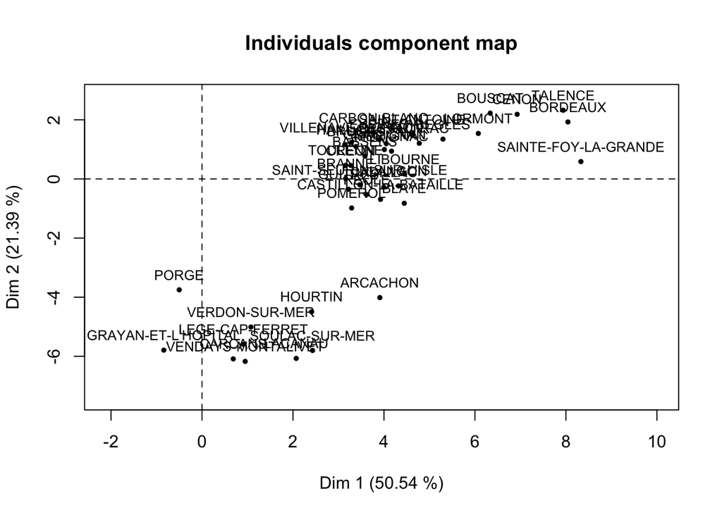

```r
plot(pcamix,choice="ind", lim.contrib.plot = 0.5, cex=0.8)
```

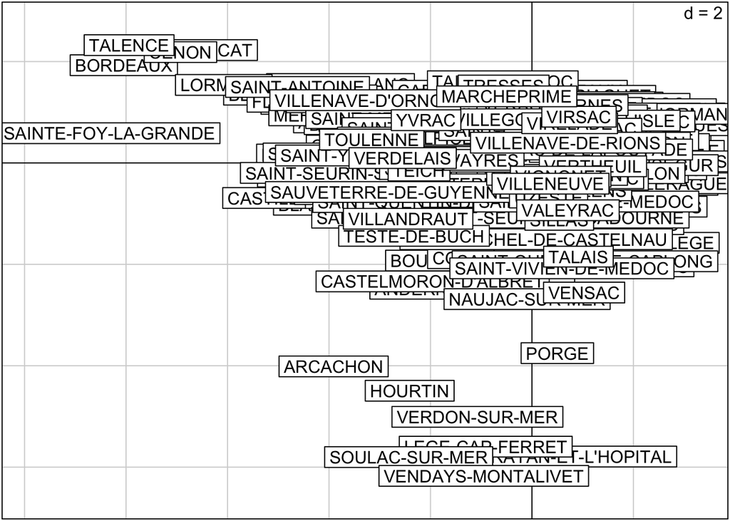

```r
s.label(dudimix$li, label = rownames(gironde$housing))
```

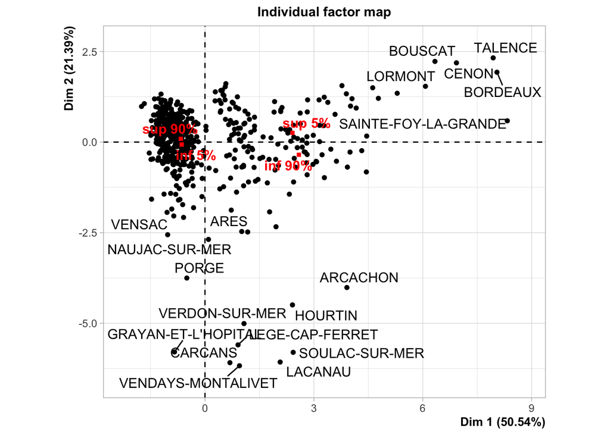

```r
plot(famd, choix="ind")
```

### Correlation circle

With `ade4` the representation of the numerical variables and the representation of the levels are necesseraly on the same plot.

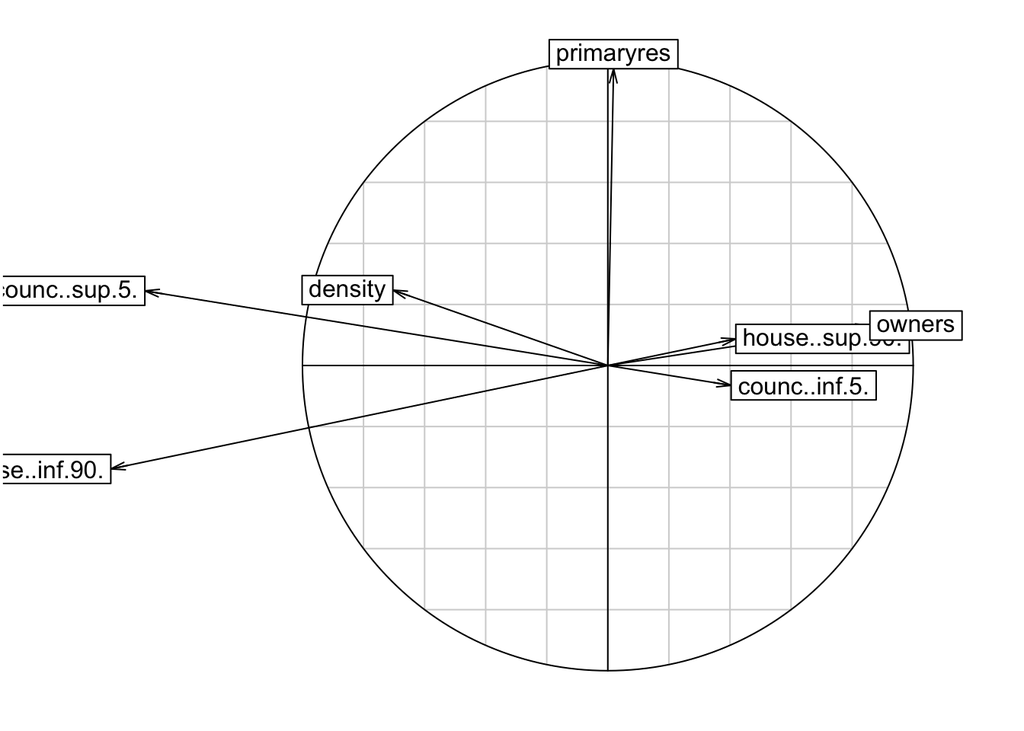

```r
s.corcircle(dudimix$co)
```

With `PCAmixdata` and `FactoMineR` the correlation circle is obtained separately.

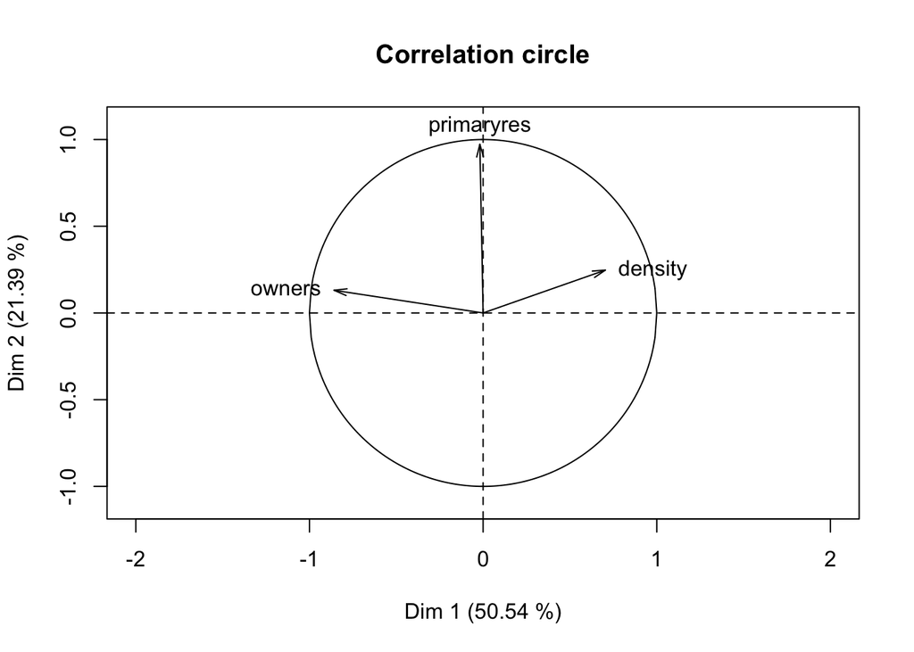

```r
plot(pcamix, choice = "cor")
```

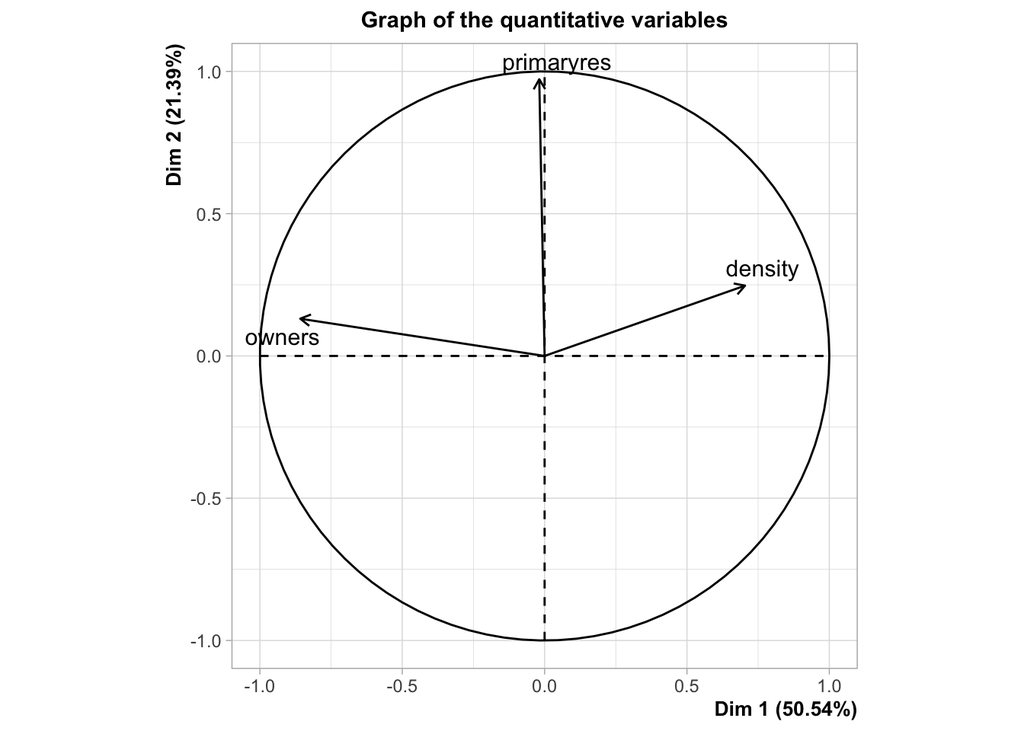

```r
plot(famd, choix = "quanti")
```

### Plot of the levels

We have seen that with **ade4** the levels are ploted on the “correlation circle”. With the two other packages a specific plot can be drawn.

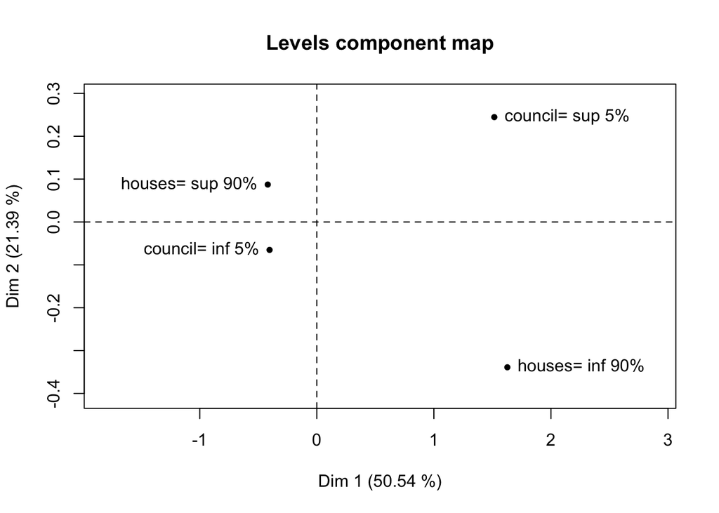

```r
plot(pcamix, choice = "levels", xlim=c(-1.5,2.4))
```

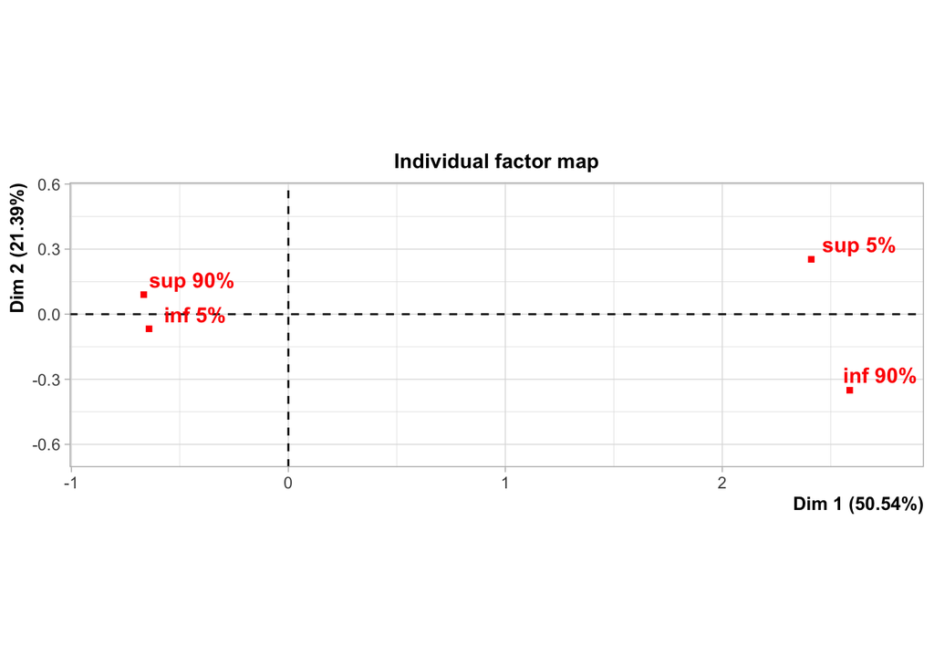

```r
plot(famd, choix = "ind", invisible = "ind")
```

## Comparison with MCA

The datatable **services** is a dataset with $p=9$ categorical variables and the same $n=542$ observations (cities).

```r
data(gironde)
services <- gironde$services
head(services)
```

```
##                    butcher  baker postoffice dentist grocery nursery doctor
## ABZAC                    0 2 or +     1 or +       0       0       0      0
## AILLAS                   0      0          0       0  1 or +       0 3 or +
## AMBARES-ET-LAGRAVE       1 2 or +     1 or +  3 or +  1 or +  1 or + 3 or +
## AMBES                    0      1     1 or +  1 to 2  1 or +       0 3 or +
## ANDERNOS-LES-BAINS  2 or + 2 or +     1 or +  3 or +  1 or +       0 3 or +
## ANGLADE                  0      1          0       0  1 or +       0      0
##                    chemist restaurant
## ABZAC                    1          1
## AILLAS                   0          1
## AMBARES-ET-LAGRAVE  2 or +     3 or +
## AMBES                    1     3 or +
## ANDERNOS-LES-BAINS  2 or +     3 or +
## ANGLADE                  0          2
```

When the data are categorical, the three functions `PCAmix`, `FADM` and `dudi.mix` perform simple multiple correspondance analysis (MCA).

```r
# MCA with PCAmix (PCAmixdata)
mca.pcamix <- PCAmix(X.quali=services,
                 rename.level=TRUE,
                 graph=FALSE, ndim=2)
# MCA with FAMD (FactoMineR)
mca.famd <- FAMD(services,
             graph = FALSE, ncp = 2)

# MCA with dudi.mix (ade4)
mca.dudimix <- dudi.mix(services,
                 scannf = FALSE, nf = 2)
```

It is also possible to use the functions- `dudi.acm` of the package **ade4** and the function `MCA` of the package **FactoMineR**.

```r
# function MCA (FactoMineR)
mca <- MCA(services,
             graph = FALSE, ncp = 2)

# function dudi.acm (ade4)
mca.dudi <- dudi.acm(services,
                 scannf = FALSE, nf = 2)
```

### Eigenvalues and principal components

The principal component scores obtained with `PCAmix`, `FADM` and `dudi.mix` are identical (as stated above).

```r
mca.pcamix$eig[1:2,1] # PCAmix, dudi.mix, FADM
```

```
## dim 1 dim 2
##   5.8   2.6
```

```r
mca.dudi$eig[1:2] # MCA with ade4
```

```
## [1] 0.64 0.29
```

```r
mca$eig[1:2,1] # MCA with FactoMineR
```

```
## dim 1 dim 2
##  0.64  0.29
```

The principal component of the functions `MCA` and `dudi.acm` must be multiplied by $\sqrt{p}$ where $p$ is the number of categorical variables. In other words, the eigenvalues should be multiplied by $p$ to get identical results.

```r
p <- ncol(services)
mca$eig[1:2,1]*p
```

```
## dim 1 dim 2
##   5.8   2.6
```

### Levels coordinates

The levels coordinates obtained with `PCAmix` and `dudi.mix` are identical but differs from that obtained with `FADM` from a factor $\sqrt{\lambda_\alpha}$. As stated above, the levels coordinates obtained with `PCAmix` and `dudi.mix` are quasi-barycenters whereas they are barycenters with `FADM`.

When the functions `MCA` and `dudi.mca` are used, the levels coordinates are identical to those obtained with `PCAmix` and `dudi.mix`.

```r
head(mca.famd$quali.var$coord)
```

```
##        Dim.1  Dim.2
## 0      -1.18 -0.043
## 1       1.21  1.101
## 2 or +  4.23 -1.167
## 0      -1.66 -0.511
## 1       0.27  1.733
## 2 or +  3.65 -0.594
```

```r
head(mca.pcamix$levels$coord)
```

```
##                dim 1  dim 2
## butcher=0      -0.49 -0.027
## butcher=1       0.50  0.686
## butcher=2 or +  1.76 -0.727
## baker=0        -0.69 -0.318
## baker=1         0.11  1.080
## baker=2 or +    1.52 -0.370
```

```r
head(mca$var$coord)
```

```
##                Dim 1  Dim 2
## butcher_0      -0.49 -0.027
## butcher_1       0.50  0.686
## butcher_2 or +  1.76 -0.727
## baker_0        -0.69 -0.318
## baker_1         0.11  1.080
## baker_2 or +    1.52 -0.370
```

```r
head(mca.dudi$co)
```

```
##                Comp1  Comp2
## butcher.0       0.49  0.027
## butcher.1      -0.50 -0.686
## butcher.2.or.. -1.76  0.727
## baker.0         0.69  0.318
## baker.1        -0.11 -1.080
## baker.2.or..   -1.52  0.370
```